# HSC Survey Results

# German Bank Survey # 3 Results from 06/09/2026

## Survey Details

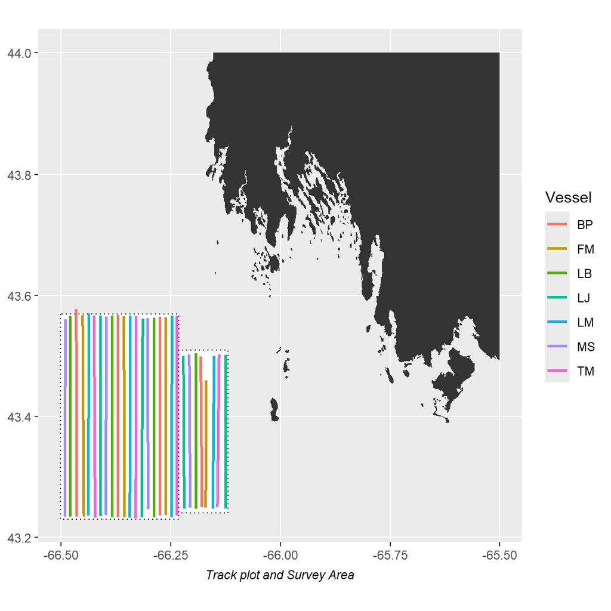

The Lady Janice II ran two transects in the German Bank box and two transects in the Seal Island box. All other vessels ran three transects in the German Bank box and one transect in the Seal Island Box.

There was a plankton tow and replicate conducted and CTD cast by Lady Janice II.

No tags were applied during this survey.

Samples were obtained for target strength estimation.

### Acoustic Equipment

Each vessel was equipped with a Simrad ES38-18/200-18C combi (2-in-1) transducer prior to the survey that contains a 38kHz split beam and 200 kHz single beam transducer. Data was logged to the computer hard-drive for post-processing. All participating boats were calibrated on 38kHz before the survey.

## Survey Results

### Main Results

The results are subject to change as DFO will re-evaluate data editing, area estimation and apply a target strength.

**Preliminary biomass prediction for German Bank using standardized parallel transects is 34,031mt, and with turnover applied 28,409mt. The preliminary biomass estimate for Seal Island is 7,503mt.**

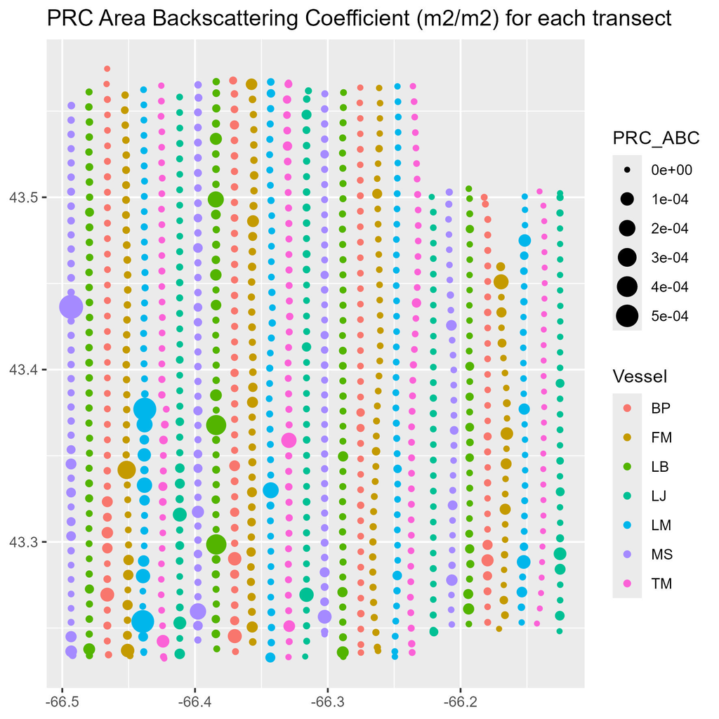

### Transect Details

Table 1: Transect Details

| Vessel | Transect # | Date/Time Start | Date/Time End | Start Lon | Start Lat | End Lon | End Lat | Location | Distance (km) | Speed |
| --- | --- | --- | --- | --- | --- | --- | --- | --- | --- | --- |
| BP | T01 | 2026-09-06 19:24:52 | 2026-09-06 21:55:05 | -66.466 | 43.578 | -66.465 | 43.234 | GB | 38.27 | 8.25 |
| BP | T02 | 2026-09-06 22:18:41 | 2026-09-07 00:46:27 | -66.372 | 43.233 | -66.371 | 43.568 | GB | 37.30 | 8.18 |
| BP | T03 | 2026-09-07 01:11:38 | 2026-09-07 03:34:53 | -66.276 | 43.565 | -66.275 | 43.236 | GB | 36.69 | 8.30 |
| BP | T04 | 2026-09-07 04:05:13 | 2026-09-07 05:32:46 | -66.180 | 43.250 | -66.182 | 43.500 | GB | 27.81 | 10.29 |
| FM | T01 | 2026-09-06 20:50:36 | 2026-09-06 23:18:36 | -66.452 | 43.568 | -66.449 | 43.234 | GB | 38.42 | 8.41 |
| FM | T02 | 2026-09-06 23:42:35 | 2026-09-07 02:10:20 | -66.357 | 43.234 | -66.357 | 43.566 | GB | 38.02 | 8.34 |
| FM | T03 | 2026-09-07 02:35:17 | 2026-09-07 05:03:10 | -66.262 | 43.564 | -66.262 | 43.237 | GB | 37.35 | 8.18 |
| FM | T04 | 2026-09-07 05:32:41 | 2026-09-07 06:59:34 | -66.171 | 43.249 | -66.170 | 43.460 | GB | 24.00 | 8.95 |
| LB | T01 | 2026-09-06 19:25:20 | 2026-09-06 21:48:37 | -66.480 | 43.566 | -66.480 | 43.234 | GB | 37.98 | 8.59 |
| LB | T02 | 2026-09-06 22:15:45 | 2026-09-07 00:57:53 | -66.384 | 43.233 | -66.384 | 43.567 | GB | 38.34 | 7.66 |
| LB | T03 | 2026-09-07 01:24:18 | 2026-09-07 03:44:46 | -66.288 | 43.564 | -66.288 | 43.233 | GB | 37.65 | 8.68 |
| LB | T04 | 2026-09-07 04:19:30 | 2026-09-07 06:04:03 | -66.194 | 43.247 | -66.194 | 43.505 | GB | 29.28 | 9.07 |
| LJ | T01 | 2026-09-06 20:07:30 | 2026-09-06 22:31:22 | -66.411 | 43.567 | -66.412 | 43.235 | GB | 37.02 | 8.34 |
| LJ | T02 | 2026-09-06 22:55:53 | 2026-09-07 01:23:32 | -66.317 | 43.233 | -66.315 | 43.562 | GB | 36.57 | 8.02 |
| LJ | T03 | 2026-09-07 01:54:47 | 2026-09-07 03:47:11 | -66.222 | 43.501 | -66.220 | 43.248 | GB | 28.13 | 8.11 |
| LJ | T04 | 2026-09-07 04:17:15 | 2026-09-07 06:07:26 | -66.125 | 43.248 | -66.125 | 43.502 | GB | 28.33 | 8.33 |
| LM | T01 | 2026-09-06 19:50:52 | 2026-09-06 22:18:51 | -66.438 | 43.571 | -66.439 | 43.236 | GB | 38.07 | 8.34 |
| LM | T02 | 2026-09-06 22:41:49 | 2026-09-07 01:07:19 | -66.344 | 43.233 | -66.343 | 43.567 | GB | 37.81 | 8.42 |
| LM | T03 | 2026-09-07 01:30:23 | 2026-09-07 03:55:45 | -66.248 | 43.567 | -66.249 | 43.233 | GB | 37.66 | 8.39 |
| LM | T04 | 2026-09-07 04:26:02 | 2026-09-07 06:17:29 | -66.155 | 43.247 | -66.152 | 43.500 | GB | 28.66 | 8.33 |
| MS | T01 | 2026-09-06 21:04:13 | 2026-09-06 23:21:05 | -66.491 | 43.561 | -66.492 | 43.234 | GB | 39.29 | 9.30 |
| MS | T02 | 2026-09-06 23:46:16 | 2026-09-07 02:16:08 | -66.399 | 43.236 | -66.398 | 43.565 | GB | 38.68 | 8.36 |
| MS | T03 | 2026-09-07 02:41:02 | 2026-09-07 04:52:54 | -66.303 | 43.563 | -66.302 | 43.246 | GB | 36.51 | 8.97 |
| MS | T04 | 2026-09-07 05:26:09 | 2026-09-07 07:03:24 | -66.206 | 43.249 | -66.209 | 43.503 | GB | 29.16 | 9.72 |
| TM | T01 | 2026-09-06 19:45:55 | 2026-09-06 22:13:13 | -66.426 | 43.567 | -66.423 | 43.232 | GB | 37.43 | 8.23 |
| TM | T02 | 2026-09-06 22:38:44 | 2026-09-07 01:18:56 | -66.331 | 43.231 | -66.330 | 43.567 | GB | 37.31 | 7.55 |
| TM | T03 | 2026-09-07 01:44:26 | 2026-09-07 04:05:41 | -66.237 | 43.566 | -66.236 | 43.236 | GB | 36.76 | 8.43 |
| TM | T04 | 2026-09-07 04:39:32 | 2026-09-07 06:11:56 | -66.144 | 43.250 | -66.141 | 43.503 | GB | 28.29 | 9.92 |

### Survey Summary

Table 2: Acoustic Survey Results

| Vessel | Transect No. | Target Strength (db/kg) | Mean Sa (/m2) | Biomass Density (kg/m2) |
| --- | --- | --- | --- | --- |
| LM | T01 | -35.5 | -43.237 | 0.168 |
| LB | T02 | -35.5 | -44.446 | 0.127 |
| MS | T01 | -35.5 | -46.203 | 0.085 |
| FM | T04 | -35.5 | -47.458 | 0.064 |
| FM | T01 | -35.5 | -47.963 | 0.057 |
| MS | T02 | -35.5 | -48.673 | 0.048 |
| BP | T02 | -35.5 | -49.013 | 0.045 |
| FM | T02 | -35.5 | -49.148 | 0.043 |
| LM | T04 | -35.5 | -49.355 | 0.041 |
| LJ | T01 | -35.5 | -49.827 | 0.037 |
| TM | T02 | -35.5 | -50.358 | 0.033 |
| BP | T01 | -35.5 | -50.637 | 0.031 |
| LM | T02 | -35.5 | -50.969 | 0.028 |
| MS | T03 | -35.5 | -51.145 | 0.027 |
| LJ | T02 | -35.5 | -51.222 | 0.027 |
| LJ | T04 | -35.5 | -51.321 | 0.026 |
| LB | T04 | -35.5 | -51.659 | 0.024 |
| BP | T04 | -35.5 | -52.030 | 0.022 |
| LB | T01 | -35.5 | -52.194 | 0.021 |
| LB | T03 | -35.5 | -52.228 | 0.021 |
| MS | T04 | -35.5 | -52.540 | 0.020 |
| TM | T01 | -35.5 | -53.687 | 0.015 |
| FM | T03 | -35.5 | -55.851 | 0.009 |
| LM | T03 | -35.5 | -56.967 | 0.007 |
| TM | T03 | -35.5 | -57.412 | 0.006 |
| LJ | T03 | -35.5 | -57.832 | 0.006 |
| BP | T03 | -35.5 | -58.100 | 0.005 |
| TM | T04 | -35.5 | -9999.000 | 0.000 |

Note:  
Transects are listed from greatest to least backscatter.

Table 3: Survey Summary Table

| Layer | Target Strength | Area (km2) | Mean Sa | Density (kg/m2) | Biomass (tons) | Percent Area | Percent Biomass | Standard Error (tons) | Standard Error (%) |
| --- | --- | --- | --- | --- | --- | --- | --- | --- | --- |
| German Bank | -35.5 | 826 | -49.3511 | 0.0404 | 34,030.90 | 75.1 | 81.9 | 7,430.17 | 21.83 |
| Seal Island | -35.5 | 274 | -51.1252 | 0.0282 | 7,502.87 | 24.9 | 18.1 | 2,049.75 | 27.32 |

### Greatest Biomass Densities

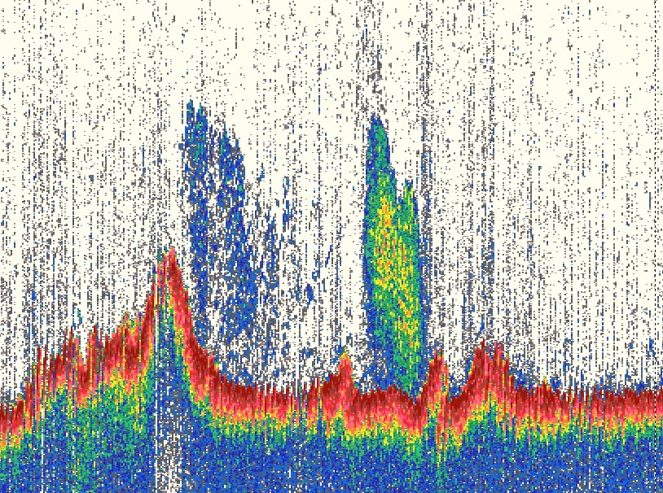

A snip from the transect with the greatest biomass density (kg/m2)

The single point with the largest biomass density (kg/m2) was recorded by **MS**, at the following location:

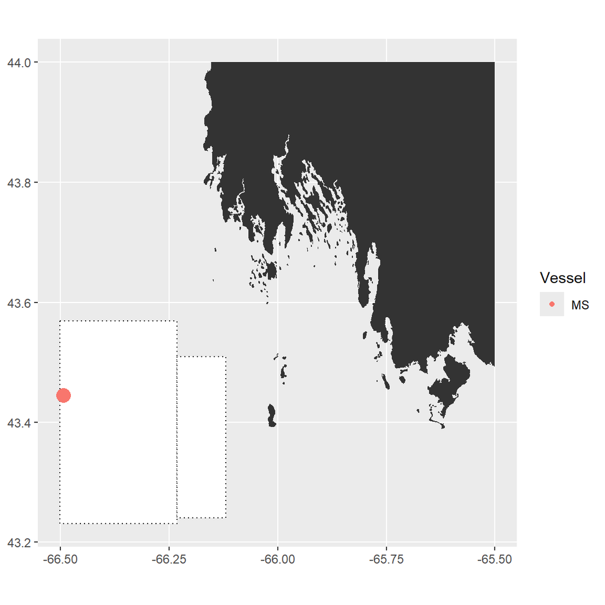

The transect with the greatest average biomass density (kg/m2) was recorded by **LM**, at the following location:

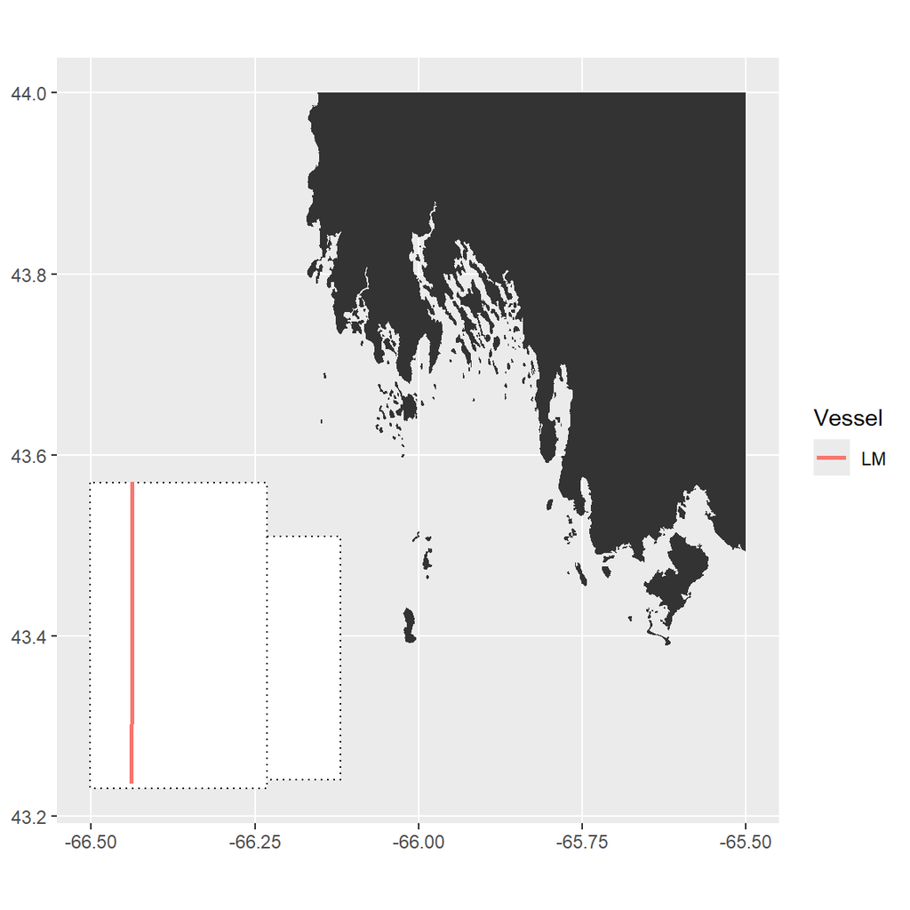

### Annual Summaries

This table does not include the biomass from adhoc surveys.

Table 4: Annual Comparison Table

| Ground | Survey Number | Current Year Survey Date | Current Year HSC Estimate | Current Year HSC Turnover Adjusted | Previous Year Survey Date | Previous Year HSC Estimate | Previous Year HSC Turnover Adjusted | Previous Year DFO Estimate | Previous Year DFO Turnover Adjusted |
| --- | --- | --- | --- | --- | --- | --- | --- | --- | --- |
| German Bank | 1 | 2026-08-09 | 51,965.016 | 51,965.02 | 2025-08-04 | 6,194 | 6,194 | NA | NA |
| Seal Island | 1 | 2026-08-09 | 7,023.005 | NA | 2025-08-04 | 1,160 | NA | NA | NA |
| German Bank | 2 | 2026-08-24 | 23,001.855 | 19,220.00 | 2025-08-18 | 35,008 | 32,592 | NA | NA |
| Seal Island | 2 | 2026-08-24 | 4,584.286 | NA | 2025-08-18 | 6,220 | NA | NA | NA |
| German Bank | 3 | 2026-09-06 | 34,030.898 | 28,409.00 | 2025-08-31 | 30,892 | 21,986 | NA | NA |
| Seal Island | 3 | 2026-09-06 | 7,502.870 | NA | 2025-08-31 | 6,500 | NA | NA | NA |
| German Bank | 4 | NA | NA | NA | 2025-09-14 | 15,323 | 7,753 | NA | NA |
| Seal Island | 4 | NA | NA | NA | 2025-09-14 | 18,112 | NA | NA | NA |
| German Bank | 5 | NA | NA | NA | 2025-09-28 | 6,754 | 2,138 | NA | NA |
| Seal Island | 5 | NA | NA | NA | 2025-09-28 | 5,048 | NA | NA | NA |
| German Bank | 6 | NA | NA | NA | 2025-10-14 | 8,611 | 7,291 | NA | NA |
| Seal Island | 6 | NA | NA | NA | 2025-10-14 | 10,346 | NA | NA | NA |
| German Bank | 7 | NA | NA | NA | 2025-10-26 | 20,039 | 17,877 | NA | NA |
| Seal Island | 7 | NA | NA | NA | 2025-10-26 | 3,433 | NA | NA | NA |

Table 5: Annual Summary Table

| Year | Ground | HSC Estimate | HSC Turnover Adjusted | DFO Estimate | DFO Turnover Adjusted |
| --- | --- | --- | --- | --- | --- |
| 2025 | German Bank | 122,821.00 | 95,831.00 | NA | NA |
| 2025 | Seal Island | 50,819.00 | NA | NA | NA |
| 2026 | German Bank | 108,997.77 | 99,594.02 | NA | NA |
| 2026 | Seal Island | 19,110.16 | NA | NA | NA |

## Plankton and CTD Data

### Plankton Data

#### Tow Summary Table

|  | Tow 1 | Tow 2 |
| --- | --- | --- |
| **Base Details** |  |  |
| Vessel | Lady Janice II | Lady Janice II |
| Set Number | GB2026-05 | GB2026-06 |
| Ground | GB | GB |
| Date | 06/09/2026 | 06/09/2026 |
| Wind Direction (km/h) | N | N |
| Swell (m) | 3 | 3 |
| Air Temp (c) | 13 | 13 |
| **Tow Details** |  |  |
| Tow Start | 19:02:00 | 19:19:00 |
| Tow End | 19:12:00 | 19:29:00 |
| Start Lat | 43.57083 | 43.56333 |
| End Lat | 43.565 | 43.565 |
| Start Lon | -66.35750 | -66.35817 |
| End Lon | -66.35850 | -66.35483 |
| Avg Tow Depth (m) | -0.04309376 | -0.04070190 |
| Speed | 1.7 | 2.2 |
| Heading | 186 | 156 |
| Tide Direction | against | against |
| **Other Data Collection** |  |  |
| Flow Start | 118059 | 148290 |
| Flow End | 148290 | 191110 |
| No. Revolutions | 30231 | 42820 |
| Distance (m) | 812.3977 | 1150.7019 |
| Volume | 2552.147 | 3614.930 |
| Secchi Disappear (m) | NA | NA |
| Secchi Reappear (m) | NA | NA |

#### Tow Depth Profiles

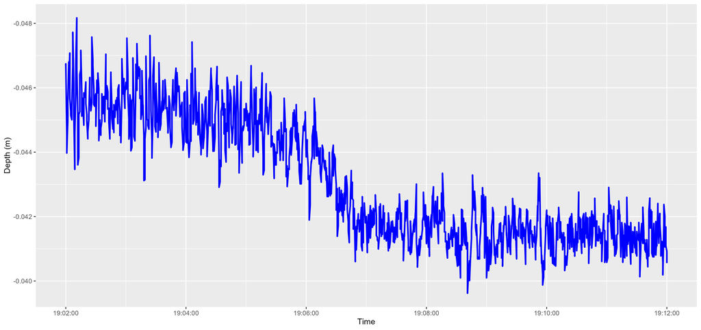

Plankton tow depth profile #1

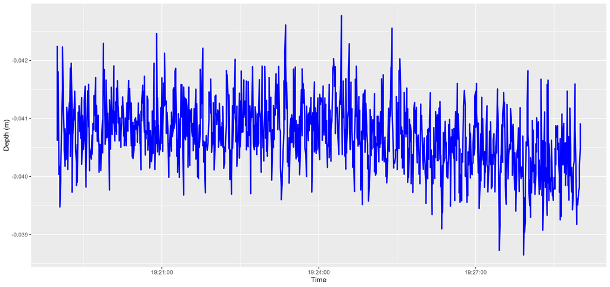

Plankton tow depth profile #2

The first tow is GB2026-05, which was against the tide and had an average depth of -0.0430938m. The second tow is GB2026-06, which was against the tide and had an average depth of -0.0407019m.

#### Captured plankton

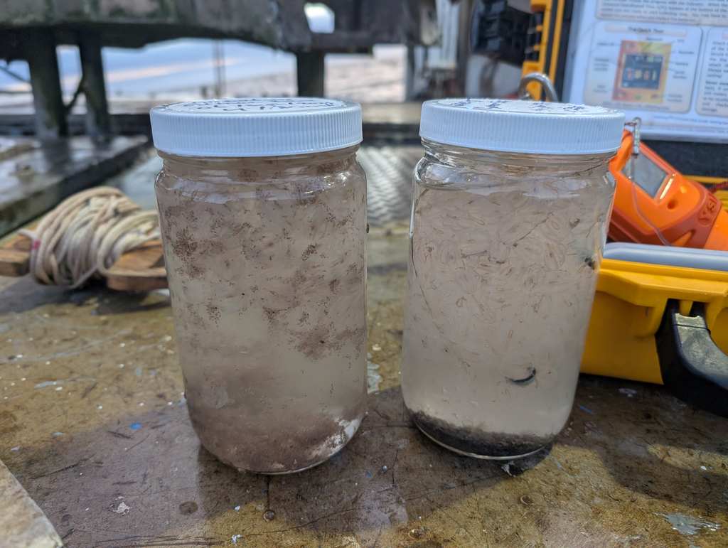

Captured plankton from the surface tows

### CTD Data

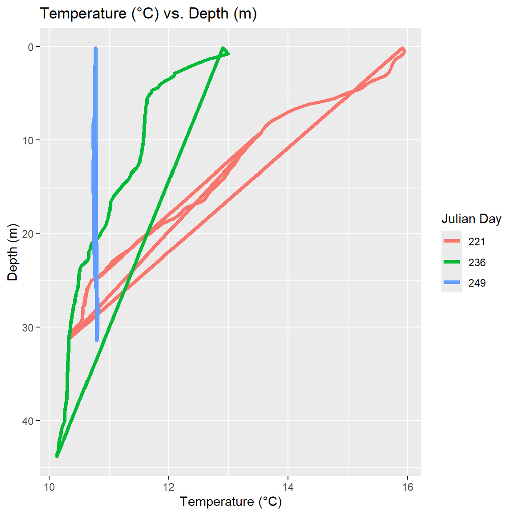

CTD depth profiles for all 2026 German Bank surveys so far.

#### Sea surface temperatures

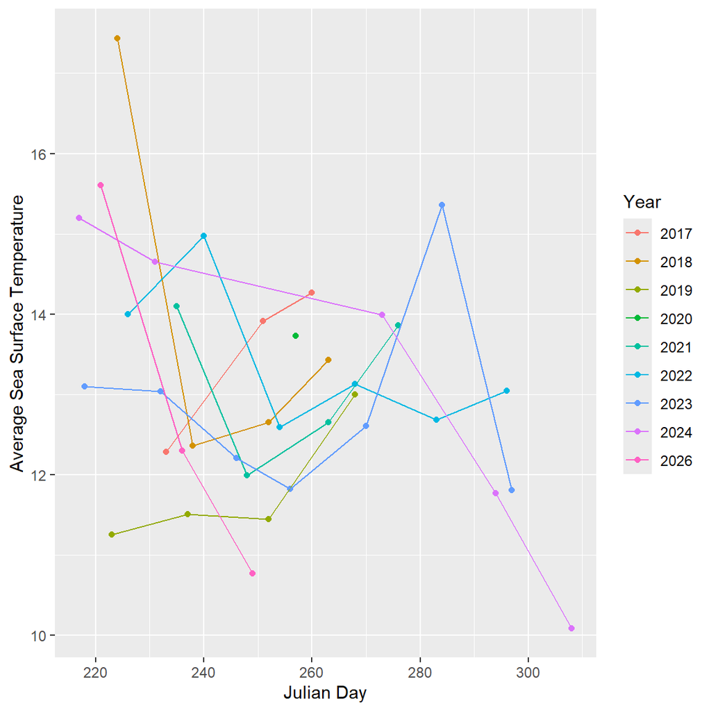

Annual average sea surface temperatures (SST) for German Bank.

## Vessel Performance

### Speed

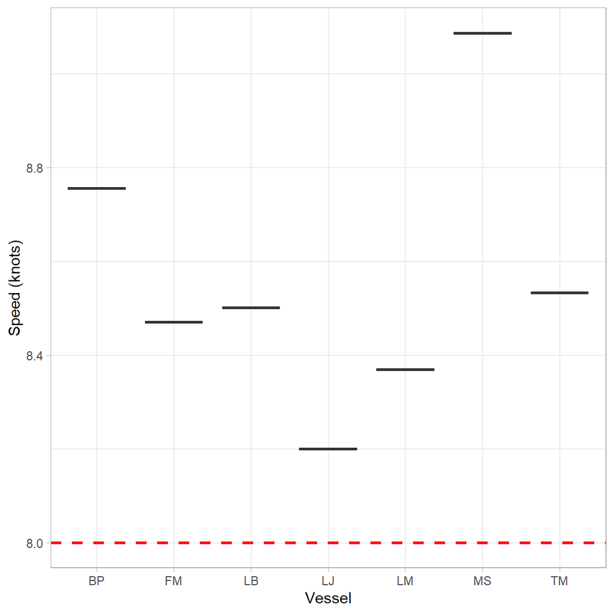

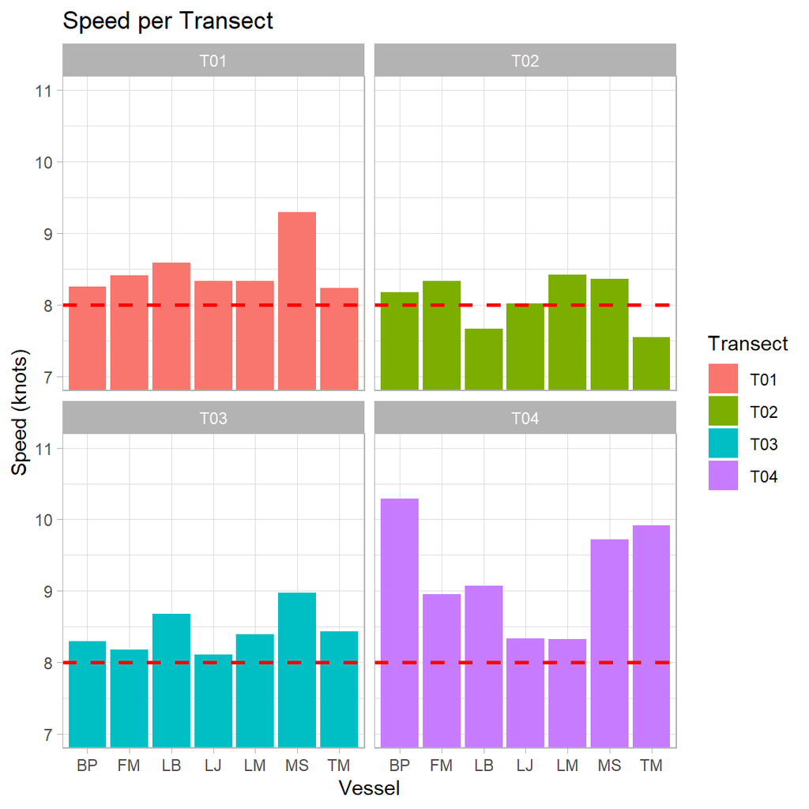

Average vessel speed was 8.56. This is above the 8 knot requirement; vessels are urged to slow down to prevent backscatter noise from interfering with the acoustic data.

The speed for each transect are rudimentary and are calculated based on distance. If a significant amount of distance is cut, the speed will appear slower.